# Part I - Ford GoBike System Data Exploration and Visualization

```python
#Created new column for weeks numbers
df_clean['start_date']= pd.to_datetime(df_clean['start_date'])

df_clean['weeks_number'] = ((df_clean['start_date'].dt.day-1)//7)+1

df_clean
```

|  | duration_sec | start_time | end_time | start_station_id | start_station_name | start_station_latitude | start_station_longitude | end_station_id | end_station_name | end_station_latitude | ... | member_birth_year | member_gender | bike_share_for_all_trip | duration_minute | start_hourofday | start_dayofweek | start_date | start_month | member_age | weeks_number |
| --- | --- | --- | --- | --- | --- | --- | --- | --- | --- | --- | --- | --- | --- | --- | --- | --- | --- | --- | --- | --- | --- |
| 0 | 52185 | 2019-02-28 17:32:10.145 | 2019-03-01 08:01:55.975 | 21.0 | Montgomery St BART Station (Market St at 2nd St) | 37.789625 | -122.400811 | 13.0 | Commercial St at Montgomery St | 37.794231 | ... | 1984 | Male | No | 869.750000 | 17 | Thursday | 2019-02-28 | February | 35 | 4 |
| 2 | 61854 | 2019-02-28 12:13:13.218 | 2019-03-01 05:24:08.146 | 86.0 | Market St at Dolores St | 37.769305 | -122.426826 | 3.0 | Powell St BART Station (Market St at 4th St) | 37.786375 | ... | 1972 | Male | No | 1030.900000 | 12 | Thursday | 2019-02-28 | February | 47 | 4 |
| 3 | 36490 | 2019-02-28 17:54:26.010 | 2019-03-01 04:02:36.842 | 375.0 | Grove St at Masonic Ave | 37.774836 | -122.446546 | 70.0 | Central Ave at Fell St | 37.773311 | ... | 1989 | Other | No | 608.166667 | 17 | Thursday | 2019-02-28 | February | 30 | 4 |
| 4 | 1585 | 2019-02-28 23:54:18.549 | 2019-03-01 00:20:44.074 | 7.0 | Frank H Ogawa Plaza | 37.804562 | -122.271738 | 222.0 | 10th Ave at E 15th St | 37.792714 | ... | 1974 | Male | Yes | 26.416667 | 23 | Thursday | 2019-02-28 | February | 45 | 4 |
| 5 | 1793 | 2019-02-28 23:49:58.632 | 2019-03-01 00:19:51.760 | 93.0 | 4th St at Mission Bay Blvd S | 37.770407 | -122.391198 | 323.0 | Broadway at Kearny | 37.798014 | ... | 1959 | Male | No | 29.883333 | 23 | Thursday | 2019-02-28 | February | 60 | 4 |
| 6 | 1147 | 2019-02-28 23:55:35.104 | 2019-03-01 00:14:42.588 | 300.0 | Palm St at Willow St | 37.317298 | -121.884995 | 312.0 | San Jose Diridon Station | 37.329732 | ... | 1983 | Female | No | 19.116667 | 23 | Thursday | 2019-02-28 | February | 36 | 4 |
| 7 | 1615 | 2019-02-28 23:41:06.766 | 2019-03-01 00:08:02.756 | 10.0 | Washington St at Kearny St | 37.795393 | -122.404770 | 127.0 | Valencia St at 21st St | 37.756708 | ... | 1989 | Male | No | 26.916667 | 23 | Thursday | 2019-02-28 | February | 30 | 4 |
| 8 | 1570 | 2019-02-28 23:41:48.790 | 2019-03-01 00:07:59.715 | 10.0 | Washington St at Kearny St | 37.795393 | -122.404770 | 127.0 | Valencia St at 21st St | 37.756708 | ... | 1988 | Other | No | 26.166667 | 23 | Thursday | 2019-02-28 | February | 31 | 4 |
| 9 | 1049 | 2019-02-28 23:49:47.699 | 2019-03-01 00:07:17.025 | 19.0 | Post St at Kearny St | 37.788975 | -122.403452 | 121.0 | Mission Playground | 37.759210 | ... | 1992 | Male | No | 17.483333 | 23 | Thursday | 2019-02-28 | February | 27 | 4 |
| 10 | 458 | 2019-02-28 23:57:57.211 | 2019-03-01 00:05:35.435 | 370.0 | Jones St at Post St | 37.787327 | -122.413278 | 43.0 | San Francisco Public Library (Grove St at Hyde... | 37.778768 | ... | 1996 | Female | Yes | 7.633333 | 23 | Thursday | 2019-02-28 | February | 23 | 4 |
| 11 | 506 | 2019-02-28 23:56:55.540 | 2019-03-01 00:05:21.733 | 44.0 | Civic Center/UN Plaza BART Station (Market St ... | 37.781074 | -122.411738 | 343.0 | Bryant St at 2nd St | 37.783172 | ... | 1993 | Male | No | 8.433333 | 23 | Thursday | 2019-02-28 | February | 26 | 4 |
| 12 | 1176 | 2019-02-28 23:45:12.651 | 2019-03-01 00:04:49.184 | 127.0 | Valencia St at 21st St | 37.756708 | -122.421025 | 323.0 | Broadway at Kearny | 37.798014 | ... | 1990 | Male | No | 19.600000 | 23 | Thursday | 2019-02-28 | February | 29 | 4 |
| 14 | 395 | 2019-02-28 23:56:26.848 | 2019-03-01 00:03:01.947 | 243.0 | Bancroft Way at College Ave | 37.869360 | -122.254337 | 252.0 | Channing Way at Shattuck Ave | 37.865847 | ... | 1988 | Male | No | 6.583333 | 23 | Thursday | 2019-02-28 | February | 31 | 4 |
| 15 | 208 | 2019-02-28 23:59:18.548 | 2019-03-01 00:02:47.228 | 349.0 | Howard St at Mary St | 37.781010 | -122.405666 | 60.0 | 8th St at Ringold St | 37.774520 | ... | 1993 | Male | Yes | 3.466667 | 23 | Thursday | 2019-02-28 | February | 26 | 4 |
| 16 | 548 | 2019-02-28 23:50:41.607 | 2019-02-28 23:59:49.953 | 131.0 | 22nd St at Dolores St | 37.755000 | -122.425728 | 71.0 | Broderick St at Oak St | 37.773063 | ... | 1981 | Male | No | 9.133333 | 23 | Thursday | 2019-02-28 | February | 38 | 4 |
| 17 | 674 | 2019-02-28 23:48:25.095 | 2019-02-28 23:59:40.092 | 74.0 | Laguna St at Hayes St | 37.776435 | -122.426244 | 336.0 | Potrero Ave and Mariposa St | 37.763281 | ... | 1975 | Male | No | 11.233333 | 23 | Thursday | 2019-02-28 | February | 44 | 4 |
| 18 | 557 | 2019-02-28 23:49:01.851 | 2019-02-28 23:58:19.809 | 321.0 | 5th St at Folsom | 37.780146 | -122.403071 | 75.0 | Market St at Franklin St | 37.773793 | ... | 1990 | Male | No | 9.283333 | 23 | Thursday | 2019-02-28 | February | 29 | 4 |
| 19 | 874 | 2019-02-28 23:43:05.183 | 2019-02-28 23:57:39.796 | 180.0 | Telegraph Ave at 23rd St | 37.812678 | -122.268773 | 180.0 | Telegraph Ave at 23rd St | 37.812678 | ... | 1978 | Male | No | 14.566667 | 23 | Thursday | 2019-02-28 | February | 41 | 4 |
| 20 | 417 | 2019-02-28 23:50:38.239 | 2019-02-28 23:57:35.852 | 72.0 | Page St at Scott St | 37.772406 | -122.435650 | 107.0 | 17th St at Dolores St | 37.763015 | ... | 1983 | Male | No | 6.950000 | 23 | Thursday | 2019-02-28 | February | 36 | 4 |
| 21 | 414 | 2019-02-28 23:50:26.879 | 2019-02-28 23:57:21.130 | 163.0 | Lake Merritt BART Station | 37.797320 | -122.265320 | 221.0 | 6th Ave at E 12th St (Temporary Location) | 37.794396 | ... | 1984 | Male | Yes | 6.900000 | 23 | Thursday | 2019-02-28 | February | 35 | 4 |
| 22 | 743 | 2019-02-28 23:44:56.439 | 2019-02-28 23:57:20.212 | 370.0 | Jones St at Post St | 37.787327 | -122.413278 | 52.0 | McAllister St at Baker St | 37.777416 | ... | 1991 | Female | No | 12.383333 | 23 | Thursday | 2019-02-28 | February | 28 | 4 |
| 23 | 367 | 2019-02-28 23:51:06.014 | 2019-02-28 23:57:13.312 | 243.0 | Bancroft Way at College Ave | 37.869360 | -122.254337 | 269.0 | Telegraph Ave at Carleton St | 37.862320 | ... | 1997 | Female | No | 6.116667 | 23 | Thursday | 2019-02-28 | February | 22 | 4 |
| 24 | 252 | 2019-02-28 23:52:51.164 | 2019-02-28 23:57:03.976 | 190.0 | West St at 40th St | 37.830223 | -122.270950 | 189.0 | Genoa St at 55th St | 37.839649 | ... | 1975 | Male | No | 4.200000 | 23 | Thursday | 2019-02-28 | February | 44 | 4 |
| 25 | 360 | 2019-02-28 23:50:31.431 | 2019-02-28 23:56:31.891 | 163.0 | Lake Merritt BART Station | 37.797320 | -122.265320 | 196.0 | Grand Ave at Perkins St | 37.808894 | ... | 1986 | Male | No | 6.000000 | 23 | Thursday | 2019-02-28 | February | 33 | 4 |
| 26 | 385 | 2019-02-28 23:49:24.399 | 2019-02-28 23:55:50.284 | 6.0 | The Embarcadero at Sansome St | 37.804770 | -122.403234 | 15.0 | San Francisco Ferry Building (Harry Bridges Pl... | 37.795392 | ... | 2000 | Male | No | 6.416667 | 23 | Thursday | 2019-02-28 | February | 19 | 4 |
| 27 | 408 | 2019-02-28 23:48:08.282 | 2019-02-28 23:54:56.930 | 78.0 | Folsom St at 9th St | 37.773717 | -122.411647 | 78.0 | Folsom St at 9th St | 37.773717 | ... | 1982 | Male | No | 6.800000 | 23 | Thursday | 2019-02-28 | February | 37 | 4 |
| 29 | 629 | 2019-02-28 23:43:48.658 | 2019-02-28 23:54:18.254 | 258.0 | University Ave at Oxford St | 37.872355 | -122.266447 | 263.0 | Channing Way at San Pablo Ave | 37.862827 | ... | 1995 | Male | No | 10.483333 | 23 | Thursday | 2019-02-28 | February | 24 | 4 |
| 30 | 163 | 2019-02-28 23:50:45.698 | 2019-02-28 23:53:29.569 | 238.0 | MLK Jr Way at University Ave | 37.871719 | -122.273068 | 244.0 | Shattuck Ave at Hearst Ave | 37.873676 | ... | 1996 | Male | Yes | 2.716667 | 23 | Thursday | 2019-02-28 | February | 23 | 4 |
| 31 | 223 | 2019-02-28 23:49:27.027 | 2019-02-28 23:53:10.535 | 28.0 | The Embarcadero at Bryant St | 37.787168 | -122.388098 | 50.0 | 2nd St at Townsend St | 37.780526 | ... | 1993 | Male | No | 3.716667 | 23 | Thursday | 2019-02-28 | February | 26 | 4 |
| 32 | 405 | 2019-02-28 23:45:39.234 | 2019-02-28 23:52:24.850 | 109.0 | 17th St at Valencia St | 37.763316 | -122.421904 | 73.0 | Pierce St at Haight St | 37.771793 | ... | 1980 | Female | No | 6.750000 | 23 | Thursday | 2019-02-28 | February | 39 | 4 |
| ... | ... | ... | ... | ... | ... | ... | ... | ... | ... | ... | ... | ... | ... | ... | ... | ... | ... | ... | ... | ... | ... |
| 183379 | 417 | 2019-02-01 00:53:10.083 | 2019-02-01 01:00:07.806 | 80.0 | Townsend St at 5th St | 37.775235 | -122.397437 | 126.0 | Esprit Park | 37.761634 | ... | 1991 | Male | No | 6.950000 | 00 | Friday | 2019-02-01 | February | 28 | 1 |
| 183380 | 943 | 2019-02-01 00:43:11.550 | 2019-02-01 00:58:55.217 | 31.0 | Raymond Kimbell Playground | 37.783813 | -122.434559 | 31.0 | Raymond Kimbell Playground | 37.783813 | ... | 1972 | Male | No | 15.716667 | 00 | Friday | 2019-02-01 | February | 47 | 1 |
| 183381 | 426 | 2019-02-01 00:48:54.159 | 2019-02-01 00:56:00.474 | 230.0 | 14th St at Mandela Pkwy | 37.810743 | -122.291415 | 213.0 | 32nd St at Adeline St | 37.823847 | ... | 1997 | Other | Yes | 7.100000 | 00 | Friday | 2019-02-01 | February | 22 | 1 |
| 183382 | 961 | 2019-02-01 00:38:29.904 | 2019-02-01 00:54:31.732 | 95.0 | Sanchez St at 15th St | 37.766219 | -122.431060 | 324.0 | Union Square (Powell St at Post St) | 37.788300 | ... | 1988 | Male | No | 16.016667 | 00 | Friday | 2019-02-01 | February | 31 | 1 |
| 183383 | 434 | 2019-02-01 00:47:11.653 | 2019-02-01 00:54:26.305 | 274.0 | Oregon St at Adeline St | 37.857567 | -122.267558 | 244.0 | Shattuck Ave at Hearst Ave | 37.873676 | ... | 1997 | Male | No | 7.233333 | 00 | Friday | 2019-02-01 | February | 22 | 1 |
| 183384 | 184 | 2019-02-01 00:50:41.579 | 2019-02-01 00:53:46.124 | 316.0 | San Salvador St at 1st St | 37.330165 | -121.885831 | 298.0 | Oak St at 1st St | 37.322125 | ... | 1991 | Male | No | 3.066667 | 00 | Friday | 2019-02-01 | February | 28 | 1 |
| 183386 | 425 | 2019-02-01 00:42:20.472 | 2019-02-01 00:49:25.515 | 239.0 | Bancroft Way at Telegraph Ave | 37.868813 | -122.258764 | 245.0 | Downtown Berkeley BART | 37.870139 | ... | 1998 | Male | Yes | 7.083333 | 00 | Friday | 2019-02-01 | February | 21 | 1 |
| 183387 | 598 | 2019-02-01 00:39:12.684 | 2019-02-01 00:49:10.791 | 239.0 | Bancroft Way at Telegraph Ave | 37.868813 | -122.258764 | 245.0 | Downtown Berkeley BART | 37.870139 | ... | 1999 | Male | Yes | 9.966667 | 00 | Friday | 2019-02-01 | February | 20 | 1 |
| 183389 | 184 | 2019-02-01 00:43:56.556 | 2019-02-01 00:47:01.009 | 66.0 | 3rd St at Townsend St | 37.778742 | -122.392741 | 47.0 | 4th St at Harrison St | 37.780955 | ... | 1985 | Other | No | 3.066667 | 00 | Friday | 2019-02-01 | February | 34 | 1 |
| 183390 | 232 | 2019-02-01 00:40:00.035 | 2019-02-01 00:43:52.880 | 239.0 | Bancroft Way at Telegraph Ave | 37.868813 | -122.258764 | 266.0 | Parker St at Fulton St | 37.862464 | ... | 1999 | Male | No | 3.866667 | 00 | Friday | 2019-02-01 | February | 20 | 1 |
| 183391 | 269 | 2019-02-01 00:37:47.527 | 2019-02-01 00:42:17.060 | 119.0 | 18th St at Noe St | 37.761047 | -122.432642 | 85.0 | Church St at Duboce Ave | 37.770083 | ... | 1980 | Male | Yes | 4.483333 | 00 | Friday | 2019-02-01 | February | 39 | 1 |
| 183392 | 1289 | 2019-02-01 00:19:45.641 | 2019-02-01 00:41:15.558 | 8.0 | The Embarcadero at Vallejo St | 37.799953 | -122.398525 | 350.0 | 8th St at Brannan St | 37.771431 | ... | 1993 | Male | No | 21.483333 | 00 | Friday | 2019-02-01 | February | 26 | 1 |
| 183393 | 155 | 2019-02-01 00:37:26.368 | 2019-02-01 00:40:01.576 | 116.0 | Mississippi St at 17th St | 37.764802 | -122.394771 | 93.0 | 4th St at Mission Bay Blvd S | 37.770407 | ... | 1985 | Male | No | 2.583333 | 00 | Friday | 2019-02-01 | February | 34 | 1 |
| 183394 | 720 | 2019-02-01 00:27:33.834 | 2019-02-01 00:39:34.233 | 26.0 | 1st St at Folsom St | 37.787290 | -122.394380 | 96.0 | Dolores St at 15th St | 37.766210 | ... | 1975 | Male | No | 12.000000 | 00 | Friday | 2019-02-01 | February | 44 | 1 |
| 183395 | 95 | 2019-02-01 00:37:23.115 | 2019-02-01 00:38:58.346 | 276.0 | Julian St at The Alameda | 37.332233 | -121.912517 | 277.0 | Morrison Ave at Julian St | 37.333658 | ... | 1993 | Male | Yes | 1.583333 | 00 | Friday | 2019-02-01 | February | 26 | 1 |
| 183396 | 576 | 2019-02-01 00:27:06.503 | 2019-02-01 00:36:43.452 | 181.0 | Grand Ave at Webster St | 37.811377 | -122.265192 | 212.0 | Mosswood Park | 37.824893 | ... | 1991 | Male | Yes | 9.600000 | 00 | Friday | 2019-02-01 | February | 28 | 1 |
| 183397 | 438 | 2019-02-01 00:28:56.101 | 2019-02-01 00:36:14.534 | 62.0 | Victoria Manalo Draves Park | 37.777791 | -122.406432 | 59.0 | S Van Ness Ave at Market St | 37.774814 | ... | 1988 | Male | No | 7.300000 | 00 | Friday | 2019-02-01 | February | 31 | 1 |
| 183398 | 1019 | 2019-02-01 00:16:59.155 | 2019-02-01 00:33:58.590 | 339.0 | Jackson St at 11th St | 37.800002 | -122.266438 | 46.0 | San Antonio Park | 37.790140 | ... | 1982 | Male | No | 16.983333 | 00 | Friday | 2019-02-01 | February | 37 | 1 |
| 183399 | 958 | 2019-02-01 00:12:24.247 | 2019-02-01 00:28:22.738 | 67.0 | San Francisco Caltrain Station 2 (Townsend St... | 37.776639 | -122.395526 | 58.0 | Market St at 10th St | 37.776619 | ... | 1993 | Male | No | 15.966667 | 00 | Friday | 2019-02-01 | February | 26 | 1 |
| 183400 | 250 | 2019-02-01 00:23:52.611 | 2019-02-01 00:28:02.679 | 356.0 | Valencia St at Clinton Park | 37.769188 | -122.422285 | 58.0 | Market St at 10th St | 37.776619 | ... | 1984 | Male | No | 4.166667 | 00 | Friday | 2019-02-01 | February | 35 | 1 |
| 183401 | 383 | 2019-02-01 00:16:48.062 | 2019-02-01 00:23:11.201 | 186.0 | Lakeside Dr at 14th St | 37.801319 | -122.262642 | 181.0 | Grand Ave at Webster St | 37.811377 | ... | 1991 | Male | Yes | 6.383333 | 00 | Friday | 2019-02-01 | February | 28 | 1 |
| 183403 | 249 | 2019-02-01 00:15:12.067 | 2019-02-01 00:19:21.699 | 256.0 | Hearst Ave at Euclid Ave | 37.875112 | -122.260553 | 247.0 | Fulton St at Bancroft Way | 37.867789 | ... | 2000 | Male | No | 4.150000 | 00 | Friday | 2019-02-01 | February | 19 | 1 |
| 183404 | 256 | 2019-02-01 00:12:50.554 | 2019-02-01 00:17:07.362 | 241.0 | Ashby BART Station | 37.852477 | -122.270213 | 248.0 | Telegraph Ave at Ashby Ave | 37.855956 | ... | 1980 | Male | Yes | 4.266667 | 00 | Friday | 2019-02-01 | February | 39 | 1 |
| 183405 | 111 | 2019-02-01 00:14:49.874 | 2019-02-01 00:16:41.301 | 324.0 | Union Square (Powell St at Post St) | 37.788300 | -122.408531 | 19.0 | Post St at Kearny St | 37.788975 | ... | 1984 | Male | No | 1.850000 | 00 | Friday | 2019-02-01 | February | 35 | 1 |
| 183406 | 706 | 2019-02-01 00:04:40.616 | 2019-02-01 00:16:27.080 | 138.0 | Jersey St at Church St | 37.750900 | -122.427411 | 78.0 | Folsom St at 9th St | 37.773717 | ... | 1988 | Male | No | 11.766667 | 00 | Friday | 2019-02-01 | February | 31 | 1 |
| 183407 | 480 | 2019-02-01 00:04:49.724 | 2019-02-01 00:12:50.034 | 27.0 | Beale St at Harrison St | 37.788059 | -122.391865 | 324.0 | Union Square (Powell St at Post St) | 37.788300 | ... | 1996 | Male | No | 8.000000 | 00 | Friday | 2019-02-01 | February | 23 | 1 |
| 183408 | 313 | 2019-02-01 00:05:34.744 | 2019-02-01 00:10:48.502 | 21.0 | Montgomery St BART Station (Market St at 2nd St) | 37.789625 | -122.400811 | 66.0 | 3rd St at Townsend St | 37.778742 | ... | 1984 | Male | No | 5.216667 | 00 | Friday | 2019-02-01 | February | 35 | 1 |
| 183409 | 141 | 2019-02-01 00:06:05.549 | 2019-02-01 00:08:27.220 | 278.0 | The Alameda at Bush St | 37.331932 | -121.904888 | 277.0 | Morrison Ave at Julian St | 37.333658 | ... | 1990 | Male | Yes | 2.350000 | 00 | Friday | 2019-02-01 | February | 29 | 1 |
| 183410 | 139 | 2019-02-01 00:05:34.360 | 2019-02-01 00:07:54.287 | 220.0 | San Pablo Ave at MLK Jr Way | 37.811351 | -122.273422 | 216.0 | San Pablo Ave at 27th St | 37.817827 | ... | 1988 | Male | No | 2.316667 | 00 | Friday | 2019-02-01 | February | 31 | 1 |
| 183411 | 271 | 2019-02-01 00:00:20.636 | 2019-02-01 00:04:52.058 | 24.0 | Spear St at Folsom St | 37.789677 | -122.390428 | 37.0 | 2nd St at Folsom St | 37.785000 | ... | 1989 | Male | No | 4.516667 | 00 | Friday | 2019-02-01 | February | 30 | 1 |

174572 rows × 23 columns

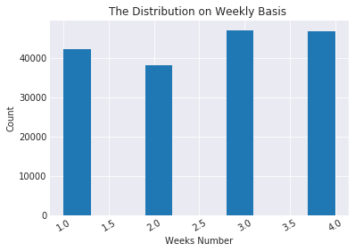

```python
# A plot illustrates the distribution over 4 weeks of February.
fig = plt.figure()
ax = fig.add_axes([.125, .125, .775, .755])
plt.hist(data= df_clean, x='weeks_number')
plt.xticks(rotation=30);
plt.title('The Distribution on Weekly Basis ')
plt.xlabel('Weeks Number')
plt.ylabel('Count');
```

### Insights:

- #### As previously shown, there is a peak in the trip distribution during typical rush hours around the hours of 8 am to 9 am and 17 pm to 18 pm during the day hours.
- #### The majority of rides happened mostly on Tuesday and Thursday, and it is obvious from the "trip distribution over day of week" plot that the primary usage was presumably for commuting.
- #### Last but not least, in terms of the distribution of rides over 4 weeks of February in 2019, the last two weeks had the most rides.

### The following plots Focus on members and users to reveal the characteristics of the riders.

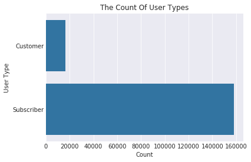

```python
# A plot illustrates the count of user types in the dataset.
fig = plt.figure()
ax = fig.add_axes([.125, .125, .775, .755])
base_color = sb.color_palette()[0]
sb.countplot(data=df_clean, y='user_type', color=base_color, ax = ax)
plt.title('The Count Of User Types')
plt.ylabel('User Type')
plt.xlabel('Count');
```

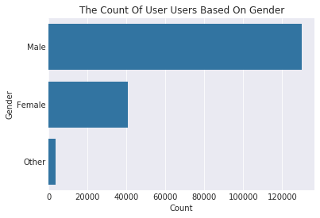

```python
# A plot illustrates the count of users based on gender in order.
fig = plt.figure()
ax = fig.add_axes([.125, .125, .775, .755])
base_color = sb.color_palette()[0]
category_order = ['Male', 'Female', 'Other']
sb.countplot(data=df_clean, y='member_gender', color=base_color, order=category_order);
plt.title('The Count Of User Users Based On Gender')
plt.ylabel('Gender');
plt.xlabel('Count');
```

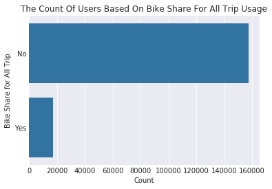

```python
# A plot illustrates the count of users based on the usage of bike_share_for_all_trip in the dataset.
fig = plt.figure()
ax = fig.add_axes([.125, .125, .775, .755])
base_color = sb.color_palette()[0]
sb.countplot(data=df_clean, y='bike_share_for_all_trip', color=base_color);
plt.title('The Count Of Users Based On Bike Share For All Trip Usage')
plt.ylabel('Bike Share for All Trip');
plt.xlabel('Count');
```

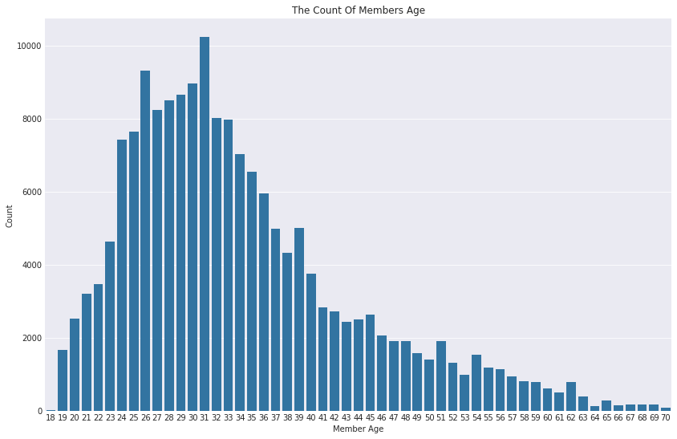

```python
# A plot illustrates the count of member age in the dataset.
plt.figure(figsize=(14, 9))
sb.countplot(data=df_clean, x='member_age', color=base_color);
plt.title('The Count Of Members Age')
plt.xlabel('Member Age')
plt.ylabel('Count');
```

### Insights:

- #### Male members made up the majority of the riders although they didn't always use the bike share service.
- #### The trip distribution plots show that the majority of trips occurred between the ages of 24 and 40, with the peak number of trips occurring during rush hours on weekdays between Monday and Friday.
- #### The use of bicycles decreased dramatically as people aged.

### Trip duration distribution to plot is next.

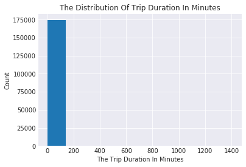

```python
# A plot illustrates the Distribution of the trip duration in minutes.
plt.hist(data=df_clean, x='duration_minute', color= base_color);
plt.title('The Distribution Of Trip Duration In Minutes')
plt.xlabel('The Trip Duration In Minutes')
plt.ylabel('Count');
```

### Insights:

```python
# Checked the data set desctiption for better overview.
```

```python
df_clean['duration_minute'].describe(percentiles=[.99])
```

```
count    174572.000000
mean         11.741151
std          27.393592
min           1.016667
50%           8.516667
99%          52.943000
max        1409.133333
Name: duration_minute, dtype: float64
```

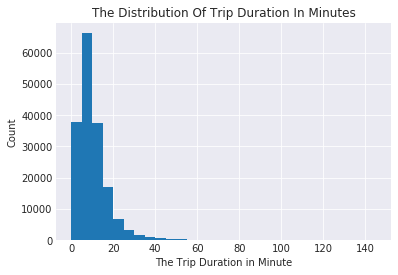

```python
# A plot illustrates the Distribution of the trip duration in minutes in more details.
plt.hist(data=df_clean, x='duration_minute', bins=bins, color= base_color);
plt.title('The Distribution Of Trip Duration In Minutes')
plt.xlabel('The Trip Duration in Minute')
plt.ylabel('Count');
```

```python
# filtered out outlier trip records where the duration was very long

df_clean = df_clean.query('duration_minute <= 66')
df_clean.info(null_counts=True)
```

```
<class 'pandas.core.frame.DataFrame'>
Int64Index: 173356 entries, 4 to 183411
Data columns (total 23 columns):
duration_sec               173356 non-null int64
start_time                 173356 non-null datetime64[ns]
end_time                   173356 non-null datetime64[ns]
start_station_id           173356 non-null object
start_station_name         173163 non-null object
start_station_latitude     173356 non-null float64
start_station_longitude    173356 non-null float64
end_station_id             173356 non-null object
end_station_name           173163 non-null object
end_station_latitude       173356 non-null float64
end_station_longitude      173356 non-null float64
bike_id                    173356 non-null object
user_type                  173356 non-null category
member_birth_year          173356 non-null int64
member_gender              173356 non-null category
bike_share_for_all_trip    173356 non-null object
duration_minute            173356 non-null float64
start_hourofday            173356 non-null object
start_dayofweek            173356 non-null object
start_date                 173356 non-null datetime64[ns]
start_month                173356 non-null object
member_age                 173356 non-null int64
weeks_number               173356 non-null int64
dtypes: category(2), datetime64[ns](3), float64(5), int64(4), object(9)
memory usage: 29.4+ MB
```

### Discuss the distribution(s) of your variable(s) of interest. Were there any unusual points? Did you need to perform any transformations?

>

> In terms of users, men outnumbered women riders, and most users—as opposed to casual riders—were subscribers. Most of the participants were between the ages of 25 and 40, and the majority did not utilize bike sharing for all of their journeys.

### Of the features you investigated, were there any unusual distributions? Did you perform any operations on the data to tidy, adjust, or change the form of the data? If so, why did you do this?

> When the initial data were plotted, the distribution of the trip duration caught us off guard. The distribution was made considerably clearer by using.describe() and xticks() to zoom in to a smaller area where the majority of trip records fell. I removed the outlier long trip records for the research using.query to help focus on the major instances of usual system use ().

```python
# save the clean data to a .csv file

df_clean.to_csv('201902-fordgobike-tripdata_clean.csv', index=False)
```

## Bivariate Exploration

### How does the trip duration distribution vary between customers and subscribers?

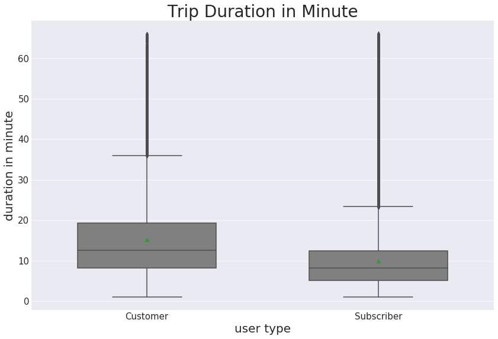

```python
# A plot illustrates the Distribution of the trip duration in minutes in more details.
import seaborn as sns
plt.figure(figsize=(14, 9))
sns.boxplot(x='user_type', y='duration_minute', data=df_clean, color='gray', width=0.6, showmeans=True)

# Made a function to customize the graph in a more Proper way.
def g_custom1(title='Trip Duration in Minute', xlabel='user type', ylabel='duration in minute'):
    plt.xticks(fontsize=15)
    plt.yticks(fontsize=15)
    plt.title(title, fontsize=28)
    plt.xlabel(xlabel, fontsize=20)
    plt.ylabel(ylabel, fontsize=20)
    sns.despine()
g_custom1()
```

### Insights:

When compared to casual riders, subscribers had a substantially narrower distribution of shorter/quicker journey durations overall. Compared to clients who vary more and typically hire the bikes for longer periods of time, subscribers appear to have a more focused usage or goal when using the bikes.

### How does the trip duration distribution vary by gender?

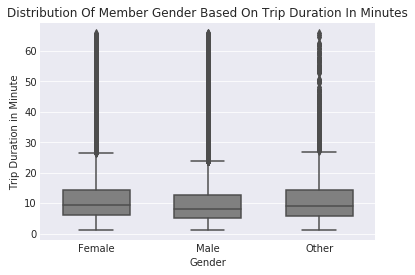

```python
# A plot illustrates the Distribution of the member gender based on trip duration in minutes.
sb.boxplot(data=df_clean, x='member_gender', y='duration_minute',color='gray', width=0.6);
plt.title('Distribution Of Member Gender Based On Trip Duration In Minutes')
plt.xlabel('Gender')
plt.ylabel('Trip Duration in Minute');
```

### Insights:

Male users often have shorter journeys than female users, while the difference is not significant, as shown by a lower median and shorter IQR.

### Average Trip Duration on Weekdays

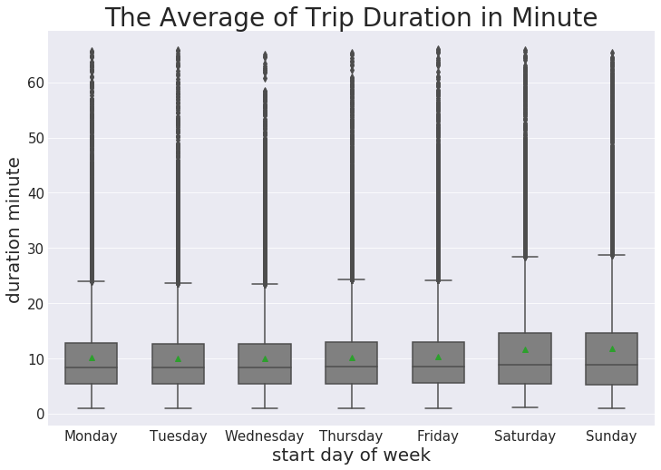

```python
# A plot illustrates the average of the trip duration in minutes.
plt.figure(figsize=(12, 8))
daysnames=["Monday", "Tuesday","Wednesday", "Thursday","Friday","Saturday","Sunday"]
sns.boxplot(x='start_dayofweek', y='duration_minute', data=df_clean, color='gray', width=0.6, showmeans=True, order=daysnames)
# Made another function to customize the graph's appearance in more proper way.
def g_custom2(title='The Average of Trip Duration in Minute',
                  xlabel='start day of week', ylabel='duration minute'):
    plt.title(title, fontsize=28)
    plt.xlabel(xlabel, fontsize=20)
    plt.ylabel(ylabel, fontsize=20)
    plt.xticks(fontsize=15)
    plt.yticks(fontsize=15)
    sns.despine()
g_custom2()
```

### Insights:

Compared to weekends, riding journeys are significantly shorter from Monday through Friday. It suggests that the sharing system is used quite consistently and effectively during regular business hours, and in a more relaxed, flexible manner on weekends.

### Average trip duration over the 4 weeks of February

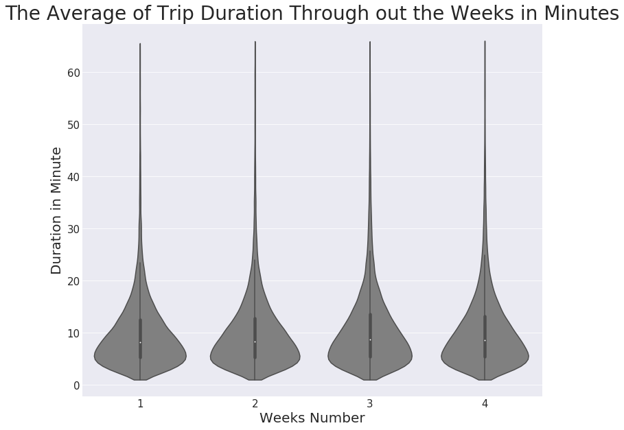

```python
# A plot illustrates the average of the trip duration on weekly basis.
plt.figure(figsize=(12, 10))
sns.violinplot(x='weeks_number', y='duration_minute', data=df_clean, color='gray', cut=0)
# Made another function to customize the graph's appearance in more proper way.
def g_custom3(title='The Average of Trip Duration Through out the Weeks in Minutes',
                  xlabel='Weeks Number', ylabel='Duration in Minute'):
    plt.title(title, fontsize=28)
    plt.xlabel(xlabel, fontsize=20)
    plt.ylabel(ylabel, fontsize=20)
    plt.xticks(fontsize=15)
    plt.yticks(fontsize=15)
    sns.despine()
g_custom3()
```

Prior to narrowing, the average usage duration showed an expanding range almost all the way through the weeks. This most likely has a lot to do with the local climate.

### Member age by weekdays

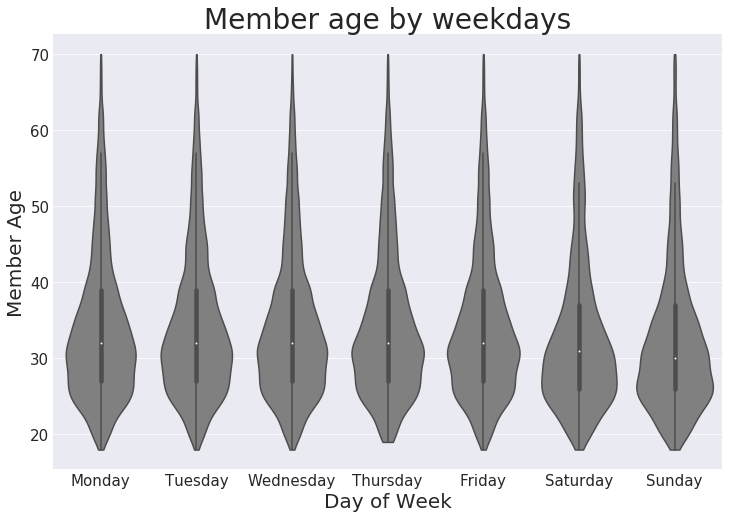

```python
# A plot illustrates the average of the trip duration in weekdays.
plt.figure(figsize=(12, 8))
daysnames1=["Monday", "Tuesday","Wednesday", "Thursday","Friday","Saturday","Sunday"]
sns.violinplot(x='start_dayofweek', y='member_age', data=df_clean, color='gray', cut=0, order=daysnames1)
# Made another function to customize the graph's appearance in more proper way.
def g_custom4(title='Member age by weekdays',xlabel='Day of Week', ylabel='Member Age'):
    plt.title(title, fontsize=28)
    plt.xlabel(xlabel, fontsize=20)
    plt.ylabel(ylabel, fontsize=20)
    plt.xticks(fontsize=15)
    plt.yticks(fontsize=15)
    sns.despine()
g_custom4()
```

It demonstrates that older users rent bikes more frequently from Monday through Friday than they do on the weekends. Correlates with the usage for commuting to work, as seen by the aforementioned univariable exploration plots.